# Project Foundations for Data Science: FoodHub Data Analysis

**Marks: 40**

### Context

The number of restaurants in New York is increasing day by day. Lots of students and busy professionals rely on those restaurants due to their hectic lifestyles. Online food delivery service is a great option for them. It provides them with good food from their favorite restaurants. A food aggregator company FoodHub offers access to multiple restaurants through a single smartphone app.

The app allows the restaurants to receive a direct online order from a customer. The app assigns a delivery person from the company to pick up the order after it is confirmed by the restaurant. The delivery person then uses the map to reach the restaurant and waits for the food package. Once the food package is handed over to the delivery person, he/she confirms the pick-up in the app and travels to the customer's location to deliver the food. The delivery person confirms the drop-off in the app after delivering the food package to the customer. The customer can rate the order in the app. The food aggregator earns money by collecting a fixed margin of the delivery order from the restaurants.

### Objective

The food aggregator company has stored the data of the different orders made by the registered customers in their online portal. They want to analyze the data to get a fair idea about the demand of different restaurants which will help them in enhancing their customer experience. Suppose you are hired as a Data Scientist in this company and the Data Science team has shared some of the key questions that need to be answered. Perform the data analysis to find answers to these questions that will help the company to improve the business.

### Data Description

The data contains the different data related to a food order. The detailed data dictionary is given below.

### Data Dictionary

- order_id: Unique ID of the order
- customer_id: ID of the customer who ordered the food
- restaurant_name: Name of the restaurant
- cuisine_type: Cuisine ordered by the customer
- cost: Cost of the order
- day_of_the_week: Indicates whether the order is placed on a weekday or weekend (The weekday is from Monday to Friday and the weekend is Saturday and Sunday)
- rating: Rating given by the customer out of 5
- food_preparation_time: Time (in minutes) taken by the restaurant to prepare the food. This is calculated by taking the difference between the timestamps of the restaurant's order confirmation and the delivery person's pick-up confirmation.
- delivery_time: Time (in minutes) taken by the delivery person to deliver the food package. This is calculated by taking the difference between the timestamps of the delivery person's pick-up confirmation and drop-off information

### Let us start by importing the required libraries

```python
# import libraries for data manipulation
import numpy as np
import pandas as pd

# import libraries for data visualization
import matplotlib.pyplot as plt
import seaborn as sns
```

### Understanding the structure of the data

```python
# read the data
df = pd.read_csv('foodhub_order.csv')
# returns the first 5 rows
df.head()
```

|  | order_id | customer_id | restaurant_name | cuisine_type | cost_of_the_order | day_of_the_week | rating | food_preparation_time | delivery_time |
| --- | --- | --- | --- | --- | --- | --- | --- | --- | --- |
| 0 | 1477147 | 337525 | Hangawi | Korean | 30.75 | Weekend | Not given | 25 | 20 |
| 1 | 1477685 | 358141 | Blue Ribbon Sushi Izakaya | Japanese | 12.08 | Weekend | Not given | 25 | 23 |
| 2 | 1477070 | 66393 | Cafe Habana | Mexican | 12.23 | Weekday | 5 | 23 | 28 |
| 3 | 1477334 | 106968 | Blue Ribbon Fried Chicken | American | 29.20 | Weekend | 3 | 25 | 15 |
| 4 | 1478249 | 76942 | Dirty Bird to Go | American | 11.59 | Weekday | 4 | 25 | 24 |

#### Observations:

The DataFrame has 9 columns as mentioned in the Data Dictionary. Data in each row corresponds to the order placed by a customer.

### **Question 1:** How many rows and columns are present in the data?

```python
print("Rows:", df.shape[0], "\nColumns:", df.shape[1])
```

```
Rows: 1898
Columns: 9
```

### **Question 2:** What are the datatypes of the different columns in the dataset? (The info() function can be used)

```python
df.info()
```

```
<class 'pandas.core.frame.DataFrame'>
RangeIndex: 1898 entries, 0 to 1897
Data columns (total 9 columns):
 #   Column                 Non-Null Count  Dtype
---  ------                 --------------  -----
 0   order_id               1898 non-null   int64
 1   customer_id            1898 non-null   int64
 2   restaurant_name        1898 non-null   object
 3   cuisine_type           1898 non-null   object
 4   cost_of_the_order      1898 non-null   float64
 5   day_of_the_week        1898 non-null   object
 6   rating                 1898 non-null   object
 7   food_preparation_time  1898 non-null   int64
 8   delivery_time          1898 non-null   int64
dtypes: float64(1), int64(4), object(4)
memory usage: 133.6+ KB
```

#### Observations:

We have 1 float, 4 integers and 4 object types.

We can see that Order ID and Customer ID are categorical variables, so we may want to change their type from int to object

```python
df=df.astype({"customer_id":object, "order_id":object})
df.info()
```

```
<class 'pandas.core.frame.DataFrame'>
RangeIndex: 1898 entries, 0 to 1897
Data columns (total 9 columns):
 #   Column                 Non-Null Count  Dtype
---  ------                 --------------  -----
 0   order_id               1898 non-null   object
 1   customer_id            1898 non-null   object
 2   restaurant_name        1898 non-null   object
 3   cuisine_type           1898 non-null   object
 4   cost_of_the_order      1898 non-null   float64
 5   day_of_the_week        1898 non-null   object
 6   rating                 1898 non-null   object
 7   food_preparation_time  1898 non-null   int64
 8   delivery_time          1898 non-null   int64
dtypes: float64(1), int64(2), object(6)
memory usage: 133.6+ KB
```

### **Question 3:** Are there any missing values in the data? If yes, treat them using an appropriate method

```python
df.isna().sum()
```

```
order_id                 0
customer_id              0
restaurant_name          0
cuisine_type             0
cost_of_the_order        0
day_of_the_week          0
rating                   0
food_preparation_time    0
delivery_time            0
dtype: int64
```

#### Observations:

We have no missing values in our data

```python
df["rating"].value_counts()["Not given"]
```

```
736
```

If we wish to treat the not given values in **rating** as missing values, then the amount of missing values in rating would be 736, we can fix this by changing it to a float/integer data type and replace the not given values with 0

```python
# Replace the not given value to 0
df['rating'] = df['rating'].replace(['Not given'],0)

# ..Then Change the data types accordingly

df = df.astype({"rating": int})


df.info()
```

```
<class 'pandas.core.frame.DataFrame'>
RangeIndex: 1898 entries, 0 to 1897
Data columns (total 9 columns):
 #   Column                 Non-Null Count  Dtype
---  ------                 --------------  -----
 0   order_id               1898 non-null   object
 1   customer_id            1898 non-null   object
 2   restaurant_name        1898 non-null   object
 3   cuisine_type           1898 non-null   object
 4   cost_of_the_order      1898 non-null   float64
 5   day_of_the_week        1898 non-null   object
 6   rating                 1898 non-null   int32
 7   food_preparation_time  1898 non-null   int64
 8   delivery_time          1898 non-null   int64
dtypes: float64(1), int32(1), int64(2), object(5)
memory usage: 126.2+ KB
```

```python
print(df["rating"].value_counts())

print("%unrated:", round((df[df["rating"]==0]["rating"].count() / df["rating"].count()) * 100, 1))
```

```
rating
0    736
5    588
4    386
3    188
Name: count, dtype: int64
%unrated: 38.8
```

### **Question 4:** Check the statistical summary of the data. What is the minimum, average, and maximum time it takes for food to be prepared once an order is placed?

```python
df.describe()
```

|  | cost_of_the_order | rating | food_preparation_time | delivery_time |
| --- | --- | --- | --- | --- |
| count | 1898.000000 | 1898.000000 | 1898.000000 | 1898.000000 |
| mean | 16.498851 | 2.659642 | 27.371970 | 24.161749 |
| std | 7.483812 | 2.195280 | 4.632481 | 4.972637 |
| min | 4.470000 | 0.000000 | 20.000000 | 15.000000 |
| 25% | 12.080000 | 0.000000 | 23.000000 | 20.000000 |
| 50% | 14.140000 | 4.000000 | 27.000000 | 25.000000 |
| 75% | 22.297500 | 5.000000 | 31.000000 | 28.000000 |
| max | 35.410000 | 5.000000 | 35.000000 | 33.000000 |

#### Observations:

Out of our 1898 observations, the minimum, maximum, and average time taken to prepare food is 20 mins, 35 mins and 27.372 mins repectively

### **Question 5:** How many orders are not rated?

```python
# Write the code here
df['rating'].value_counts()
```

```
rating
0    736
5    588
4    386
3    188
Name: count, dtype: int64
```

#### Observations:

Since we replaced all of the values where no rating was given to 0, the amount of orders where no rating was given is 736

### Exploratory Data Analysis (EDA)

### **Question 6:** Explore all the variables and provide observations on their distributions. (Generally, histograms, boxplots, countplots, etc. are used for univariate exploration)

### Based on Cost of Orders

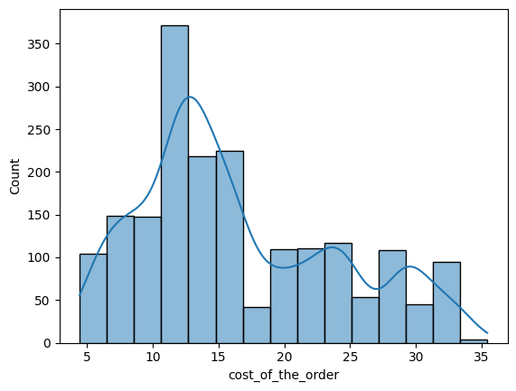

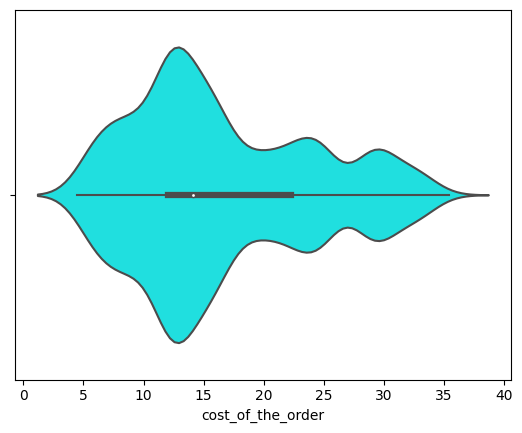

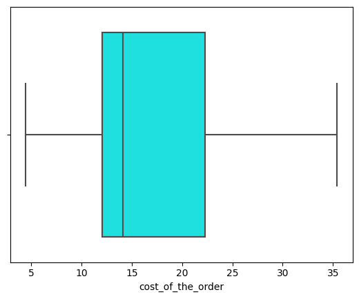

```python
sns.histplot(data=df, x="cost_of_the_order", bins=15, kde=True)
plt.show()
sns.violinplot(data=df, x="cost_of_the_order", color="cyan")
plt.show()
sns.boxplot(data=df, x="cost_of_the_order", color="cyan")
```

#### Observation:

Our boxplot/Violinplot illustrates that the median cost is around 13-14 dollars, with the results being skewed to the right

### Based on Cuisine Type

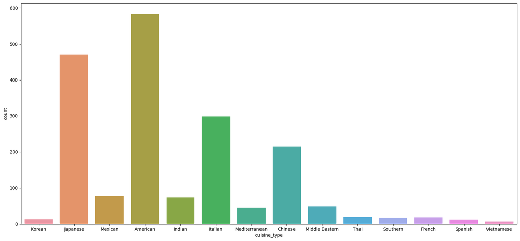

```python
plt.figure(figsize=(20,9))
sns.countplot(data=df, x='cuisine_type')
```

#### Observation:

The most popular cuisines are American, Japanese, Italian and Chinese, followed by Mexican, Indian, Middle Eastern and Mediterranean in that order

### Based on Ratings

Since all orders rated 0 were originally not rated, we won't be tasking them into consideration in our readings

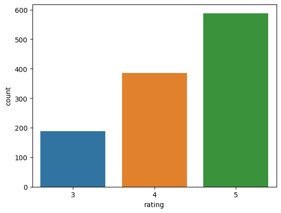

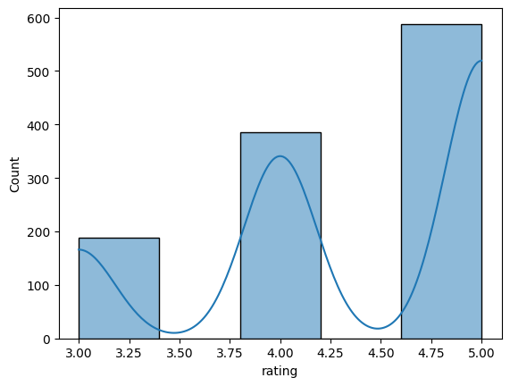

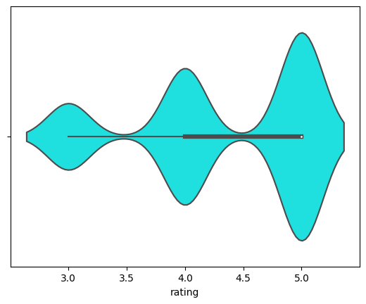

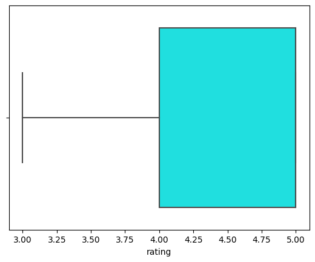

```python
sns.countplot(data=df[df["rating"]!=0], x="rating")
plt.show()
sns.histplot(data=df[df["rating"]!=0], x="rating", bins=5, kde=True)
plt.show()
sns.violinplot(data=df[df["rating"]!=0], x="rating", color="cyan")
plt.show()
sns.boxplot(data=df[df["rating"]!=0], x="rating", color="cyan")
```

### Observations:

On the Histplot and Countplot Ratings of the orders is heavily concentrated towards the higher ratings

On the boxplot/Violinplot, the orders are so heacily skewed to the left that we dont have a right whisker

#### Based on days of the week

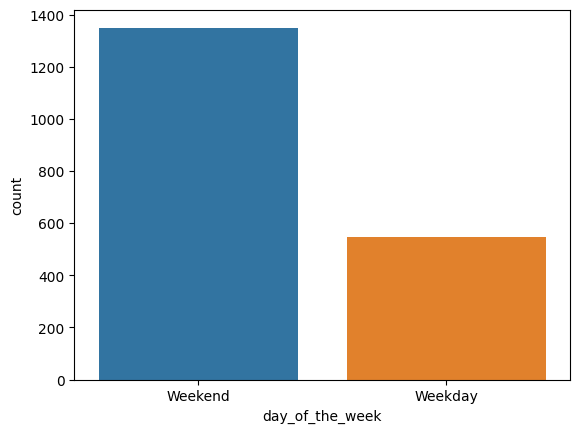

```python
sns.countplot(data=df, x="day_of_the_week")
plt.show()
```

#### Observations:

More people prefer to order food on weekends over weekdays

#### Based on Preparation time

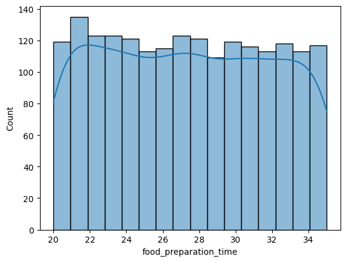

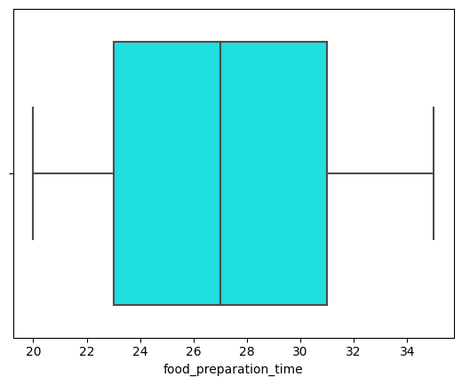

```python
sns.histplot(data=df, x="food_preparation_time", bins=16, kde=True)
plt.show()
sns.boxplot(data=df, x="food_preparation_time", color="cyan")
```

#### Observations:

Based on the histogram, the preparsation time of food is very even between 20 and 35 minutes

Based on boxplot, the median is sround 27 minutes

#### Based on delivery time

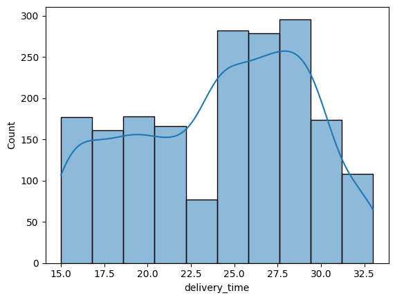

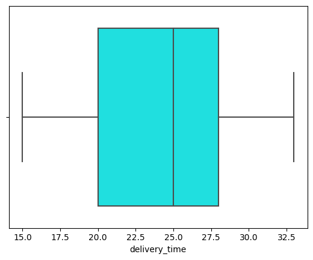

```python
sns.histplot(data=df, x="delivery_time", bins=10, kde=True)
plt.show()
sns.boxplot(data=df, x="delivery_time", color="cyan")
```

#### Observations:

From the histplot, we can see most orders are delivered around 24-29 minutes

From boxplot, we observe that the observations are left skewed with the median being around 25 minutes

### **Question 7**: Which are the top 5 restaurants in terms of the number of orders received?

```python
df["restaurant_name"].value_counts().head(5)

#Another way to do this would be to use group by and count functions

#example -> df[["restaurant_name", "customer_id"]].groupby("restaurant_name").count().sort_values(by="customer_id", ascending=False).head(5)
```

```
restaurant_name
Shake Shack                  219
The Meatball Shop            132
Blue Ribbon Sushi            119
Blue Ribbon Fried Chicken     96
Parm                          68
Name: count, dtype: int64
```

#### Observations:

The top 5 restaurants are *Shake Shack(**219 orders**)*, *The Meatball Shop(**132 orders**)*, *Blue Ribbon Sushi(**119 orders**)*, *Blue Ribbon Fried Chicken(**96 orders**)* and *Parm(**68 orders**)* respectively

### **Question 8**: Which is the most popular cuisine on weekends?

```python
df[df["day_of_the_week"]=="Weekend"]["cuisine_type"].value_counts().head(5)
#Another way to do this would be to use group by and count functions

#example -> df[df["day_of_the_week"]=="Weekend"][["cuisine_type", "customer_id"]].groupby("cuisine_type").count().sort_values(by="customer_id", ascending=False).head(5)
```

```
cuisine_type
American    415
Japanese    335
Italian     207
Chinese     163
Mexican      53
Name: count, dtype: int64
```

#### Observations:

*American cuisine(**415 orders**)* is the most popular cuisine type on weekends

### **Question 9**: What percentage of the orders cost more than 20 dollars?

```python
total = df.cost_of_the_order.count()
orders_above_20 = df.cost_of_the_order[df["cost_of_the_order"]>20].count()

print((orders_above_20/total)*100)
```

```
29.24130663856691
```

#### Observations:

Approximately 29.24% of the orders cost more than $20

### **Question 10**: What is the mean order delivery time?

```python
round(df.describe()["delivery_time"]["mean"],2)
```

```
24.16
```

#### Observations:

Delivery time is 24.16 minutes on average

### **Question 11:** The company has decided to give 20% discount vouchers to the top 3 most frequent customers. Find the IDs of these customers and the number of orders they placed

```python
df["customer_id"].value_counts().head(3)

#Another way to do this would be to use group by and count functions

#example -> df[["customer_id","order_id"]].groupby("customer_id").count().sort_values(by="order_id", ascending=False).head()
```

```
customer_id
52832    13
47440    10
83287     9
Name: count, dtype: int64
```

#### Observations:

The top 3 most frequent customers are 52832(**13 orders**), 47440(**10 orders**), 83287(**9 orders**)

### **Question 12**: Perform a multivariate analysis to explore relationships between the important variables in the dataset. (It is a good idea to explore relations between numerical variables as well as relations between numerical and categorical variables)

### Based on Rating of consumer vs delivery time

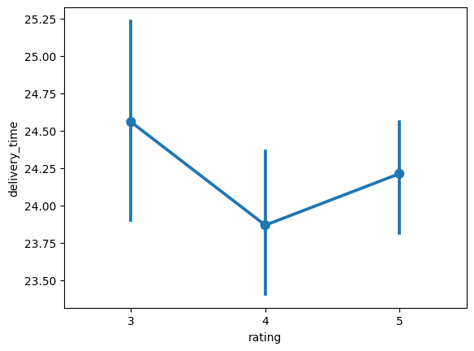

```python
sns.pointplot(data=df[df["rating"]!=0], x="rating", y="delivery_time")
plt.show()
```

### Based on cost of order per cuisine per day of the week

[output not shown]

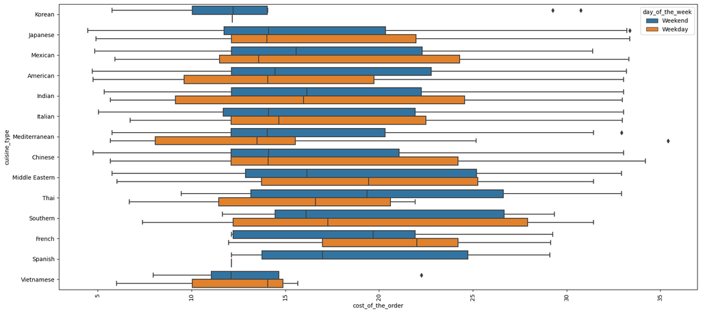

```python
plt.figure(figsize=(20,9))
sns.boxplot(data=df, y="cuisine_type", x="cost_of_the_order", hue="day_of_the_week")
plt.xticks(rotation=90)
```

### Based on amount of orders per weekday per cuisine

[output not shown]

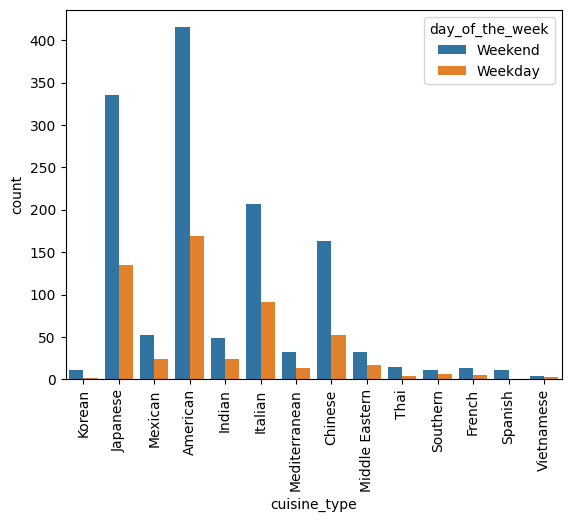

```python
sns.countplot(data=df, x="cuisine_type", hue="day_of_the_week")
plt.xticks(rotation=90)
```

### Based on food preparation time per cuisine

[output not shown]

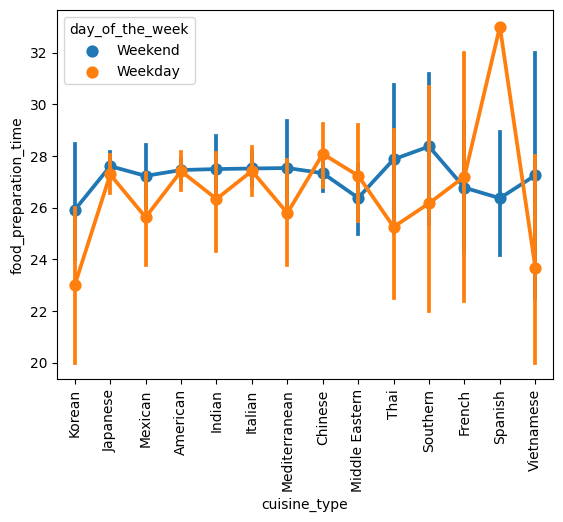

```python
sns.pointplot(df, x="cuisine_type", y="food_preparation_time", hue="day_of_the_week")
plt.xticks(rotation=90)
```

### Day of the week vs food delivery time

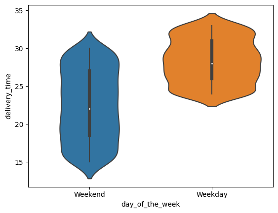

```python
sns.violinplot(data= df, x="day_of_the_week", y="delivery_time")
```

### **Question 13:** The company wants to provide a promotional offer in the advertisement of the restaurants. The condition to get the offer is that the restaurants must have a rating count of more than 50 and the average rating should be greater than 4. Find the restaurants fulfilling the criteria to get the promotional offer

```python
dfmean = df[["restaurant_name","rating"]][df["rating"]!= 0].groupby('restaurant_name').mean()>4
dfcount = df[["restaurant_name","rating"]][df["rating"]!= 0].groupby('restaurant_name').count()>50
pd.merge(dfmean[dfmean['rating']==True], dfcount[dfcount['rating']==True], on="restaurant_name")
```

| restaurant_name | rating_x | rating_y |
| --- | --- | --- |
| Blue Ribbon Fried Chicken | True | True |
| Blue Ribbon Sushi | True | True |
| Shake Shack | True | True |
| The Meatball Shop | True | True |

#### Observations:

Blue Ribbon Fried Chicken, Blue Ribbon Sushi, Shake Shack, and The Meatball Shop qualify for the promotional offer

### **Question 14:** The company charges the restaurant 25% on the orders having cost greater than 20 dollars and 15% on the orders having cost greater than 5 dollars. Find the net revenue generated by the company across all orders

#### Variables used:

*rev* - is total revenue generated

*cost* - is a pandas series of cost of orders from our data

*x* - is the income generated from each order systematically

```python
#rev and x are initialized to zero before our loop begins
x = 0
rev = 0

#cost is assigned the cost_of_the_order column from our dataframe as a series
cost = pd.Series(df["cost_of_the_order"])
```

```python
#Running loop using cost to calculate revenue generated

for i in range(len(cost)):
    if cost[i]>20:
        income = cost[i] * 0.25
    elif (cost[i]>5) & (cost[i]<20):
        income = cost[i] * 0.15
    else:
        income = 0

    rev = rev + income
print("$", round(rev, 2), sep="")
```

```
$6166.3
```

#### Observations:

Revenue generated by FoodHub is **$6166.30** based on the data given

### **Question 15:** The company wants to analyze the total time required to deliver the food. What percentage of orders take more than 60 minutes to get delivered from the time the order is placed? (The food has to be prepared and then delivered)

```python
# Percent of orders above 60mins = (No. of Orders with delivery time over 60mins / Total Orders) * 100
percent60above = (df[df["food_preparation_time"] + df["delivery_time"]>60]["order_id"].count() / df["order_id"].count()) * 100

print(round(percent60above,2), "%" , sep="")
```

```
10.54%
```

#### Observations:

About **10.54%** of orders take more than 60 minutes to reach the customer from the time the order was placed

### **Question 16:** The company wants to analyze the delivery time of the orders on weekdays and weekends. How does the mean delivery time vary during weekdays and weekends?

```python
df.groupby("day_of_the_week")[["delivery_time"]].mean()
```

| day_of_the_week | delivery_time |
| --- | --- |
| Weekday | 28.340037 |
| Weekend | 22.470022 |

#### Observations:

We can see that average delivery time during the weekends is **22.47mins** compared to **28.34mins** during the weekdays

This can be due to higher traffic during working hours on weekdays compared to weekends